# Machine Learning Assignment

Muralidharan S

February 24, 2016

### Introduction

Six participants were asked to perform barbell lifts correctly and incorrectly in 5 different ways. We have data for the 6 participants from accelerometers on the belt, forearm, arm, and dumbell. There is a variable “Classe” in the dataset which tells the manner in which the six participants did the exercise.

Class A - exactly according to the specification. Class B - throwing the elbows to the front. Class C - lifting the dumbbell only halfway. Class D - lowering the dumbbell only halfway. Class E - throwing the hips to the front.

The data for this project come from this source: http://groupware.les.inf.puc-rio.br/har.

The objective of the project is to develop a model to predict the class of people given a set of measurements/readings from the accelometer.

### Data Collection

The training and the test data sets are collected. The model development and training will be done on the training dataset and so the test set is aside and is only used when predicting values for the 20 cases.

```r
set.seed(100)
training<-read.csv("pml-training.csv",na.strings = c(""," ","NA"))
testing<-read.csv("pml-testing.csv",na.strings = c(""," ","NA"))
```

### Splitting the training data set

Now the training dataset is split into 2. One is used for model training and development and the other is used as validation/hold out dataset.

```r
set.seed(101)
library(caret)
inTrain<-createDataPartition(y=training$classe,p=0.7,list = FALSE)
training_train<-training[inTrain,]
training_test<-training[-inTrain,]
```

### Covariate creation

The first step is to look at variables that have close to zero variance and thereby do not contribute the prediction of the dependent variable in any way. These variables are better removed from the model.

```r
set.seed(102)
training_train_zv<-nearZeroVar(training_train,saveMetrics = FALSE)
training_train_2<-training_train[,-c(training_train_zv)]
```

The vector “training_train_zv” has the variable positions which have nearly zero variance and can be removed from the training set.

The next step is to look at variables which have missing data.

```r
set.seed(103)
Missing_data <- function(x){sum(is.na(x))/length(x)*100}
apply(training_train_2,2,Missing_data)
```

```
##                        X                user_name     raw_timestamp_part_1
##                  0.00000                  0.00000                  0.00000
##     raw_timestamp_part_2           cvtd_timestamp               num_window
##                  0.00000                  0.00000                  0.00000
##                roll_belt               pitch_belt                 yaw_belt
##                  0.00000                  0.00000                  0.00000
##         total_accel_belt       kurtosis_roll_belt      kurtosis_picth_belt
##                  0.00000                 97.85979                 97.85979
##       skewness_roll_belt     skewness_roll_belt.1            max_roll_belt
##                 97.85979                 97.85979                 97.85979
##           max_picth_belt             max_yaw_belt            min_roll_belt
##                 97.85979                 97.85979                 97.85979
##           min_pitch_belt             min_yaw_belt      amplitude_roll_belt
##                 97.85979                 97.85979                 97.85979
##     amplitude_pitch_belt     var_total_accel_belt            avg_roll_belt
##                 97.85979                 97.85979                 97.85979
##         stddev_roll_belt            var_roll_belt           avg_pitch_belt
##                 97.85979                 97.85979                 97.85979
##        stddev_pitch_belt           var_pitch_belt             avg_yaw_belt
##                 97.85979                 97.85979                 97.85979
##          stddev_yaw_belt             var_yaw_belt             gyros_belt_x
##                 97.85979                 97.85979                  0.00000
##             gyros_belt_y             gyros_belt_z             accel_belt_x
##                  0.00000                  0.00000                  0.00000
##             accel_belt_y             accel_belt_z            magnet_belt_x
##                  0.00000                  0.00000                  0.00000
##            magnet_belt_y            magnet_belt_z                 roll_arm
##                  0.00000                  0.00000                  0.00000
##                pitch_arm                  yaw_arm          total_accel_arm
##                  0.00000                  0.00000                  0.00000
##            var_accel_arm              gyros_arm_x              gyros_arm_y
##                 97.85979                  0.00000                  0.00000
##              gyros_arm_z              accel_arm_x              accel_arm_y
##                  0.00000                  0.00000                  0.00000
##              accel_arm_z             magnet_arm_x             magnet_arm_y
##                  0.00000                  0.00000                  0.00000
##             magnet_arm_z         kurtosis_yaw_arm         skewness_yaw_arm
##                  0.00000                 97.85979                 97.85979
##             max_roll_arm            max_picth_arm              max_yaw_arm
##                 97.85979                 97.85979                 97.85979
```

[output cut: 27 more lines]

```
##                  0.00000                  0.00000                  0.00000
##              yaw_forearm        max_picth_forearm          max_yaw_forearm
##                  0.00000                 97.85979                 97.85979
##        min_pitch_forearm          min_yaw_forearm  amplitude_pitch_forearm
##                 97.85979                 97.85979                 97.85979
##    amplitude_yaw_forearm      total_accel_forearm        var_accel_forearm
##                 97.85979                  0.00000                 97.85979
##          gyros_forearm_x          gyros_forearm_y          gyros_forearm_z
##                  0.00000                  0.00000                  0.00000
##          accel_forearm_x          accel_forearm_y          accel_forearm_z
##                  0.00000                  0.00000                  0.00000
##         magnet_forearm_x         magnet_forearm_y         magnet_forearm_z
##                  0.00000                  0.00000                  0.00000
##                   classe
##                  0.00000
```

There are many variables/features with more than 95% missing data in it. These variables are not going to contribute to the prediction of the dependent variable in a meaningful way. So we will remove these variables.

```r
set.seed(104)
missing_train_pos<-which(colSums(is.na(training_train_2))>0)
training_train_3<-training_train_2[,-c(missing_train_pos)]
```

Finally three additional variables are removed from the model. They are X, UserName and Numwindow.

```r
set.seed(105)
training_train_4<-training_train_3[,-c(1,2,6)]
```

Doing the same processing on the dataset for the validation/hold out set as well below.

```r
set.seed(106)
training_test_2<-training_test[,-c(training_train_zv)]
training_test_3<-training_test_2[,-c(missing_train_pos)]
training_test_4<-training_test_3[,-c(1,2,6)]
```

### Preprocessing

As there are a lot of correlated predictor variables we will use the principal component analysis method to bring down the number of variables. We will use the option method=“pca” in the train function in the caret package. The skewness in the individual variables can be removed by centering and scaling the variables. The “pca” method does the centering and scaling as well.

```r
set.seed(107)
correlation<-abs(cor(training_train_4[,c(-1,-2,-3,-56)]))
diag(correlation)<-0
which(correlation>0.8,arr.ind = T)
```

```
##                  row col
## yaw_belt           3   1
## total_accel_belt   4   1
## accel_belt_y       9   1
## accel_belt_z      10   1
## accel_belt_x       8   2
## magnet_belt_x     11   2
## roll_belt          1   3
## roll_belt          1   4
## accel_belt_y       9   4
## accel_belt_z      10   4
## pitch_belt         2   8
## magnet_belt_x     11   8
## roll_belt          1   9
## total_accel_belt   4   9
## accel_belt_z      10   9
## roll_belt          1  10
## total_accel_belt   4  10
## accel_belt_y       9  10
## pitch_belt         2  11
## accel_belt_x       8  11
## gyros_arm_y       19  18
## gyros_arm_x       18  19
## magnet_arm_x      24  21
## accel_arm_x       21  24
## magnet_arm_z      26  25
## magnet_arm_y      25  26
## accel_dumbbell_x  34  28
## accel_dumbbell_z  36  29
## gyros_dumbbell_z  33  31
## gyros_forearm_z   46  31
## gyros_dumbbell_x  31  33
## gyros_forearm_z   46  33
## pitch_dumbbell    28  34
## yaw_dumbbell      29  36
## gyros_forearm_z   46  45
## gyros_dumbbell_x  31  46
## gyros_dumbbell_z  33  46
## gyros_forearm_y   45  46
```

### Plotting the predictors

It is important to plot the predictors to understand the variablility of the variables for each class or response. Also the plots help us understand the outliers and variables that are very skewed.

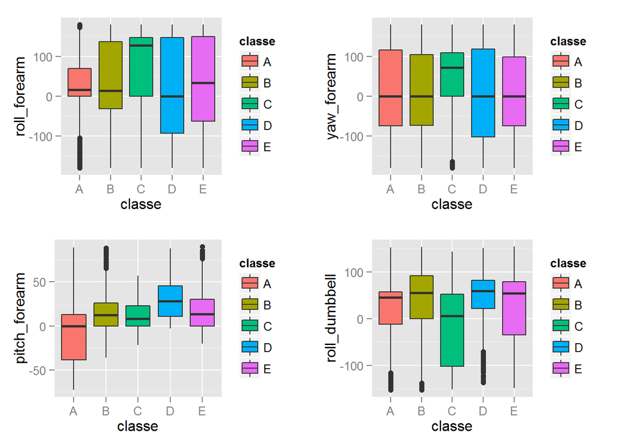

```r
set.seed(108)
library(Rmisc)
plot1<-qplot(classe,roll_forearm,data = training_train_4,fill=classe,geom=c("boxplot"))
plot2<-qplot(classe,pitch_forearm,data = training_train_4,fill=classe,geom=c("boxplot"))
plot3<-qplot(classe,yaw_forearm,data = training_train_4,fill=classe,geom=c("boxplot"))
plot4<-qplot(classe,roll_dumbbell,data = training_train_4,fill=classe,geom=c("boxplot"))
library(Rmisc)
multiplot(plot1,plot2,plot3,plot4,cols = 2)
```

### Model training and Selection

The first step in building and training a model is to choose the most appropriate method to train. As the response is one of five classes this is one of classification problems. Classification with regression tree is the most appropriate method.

#### Model 1

```r
set.seed(109)
modfit_rpart<-train(classe~.,data = training_train_4,method="rpart",preProcess=c("center","scale"))
```

#### Model 2

```r
set.seed(110)
modfit_rpart_2<-train(classe~.,data = training_train_4,method="rpart",preProcess=c("pca"))
```

#### Model 3

```r
set.seed(111)
modfit_bagging<-train(classe~.,data = training_train_4,method="treebag",preProcess=c("pca"))
```

Model 3 uses “treebag” method. This is Bagging method wherein several models are created using bootstrapping and then the models are averaged to get an aggregate model. Bagging is an extension of“rpart” algorithm.

We will look at the accuracy of the models using confusion matrix.

#### Confusion Matrix for Model 1

```r
set.seed(112)
pred_train_test_rpart<-predict(modfit_rpart,training_test_4[,-56])
confusionMatrix(pred_train_test_rpart,training_test_4$classe)
```

```
## Confusion Matrix and Statistics
##
##           Reference
## Prediction    A    B    C    D    E
##          A 1365  579  145  325   98
##          B    0    0    0    0    0
##          C  304  560  881  639  492
##          D    0    0    0    0    0
##          E    5    0    0    0  492
##
## Overall Statistics
##
##                Accuracy : 0.4653
##                  95% CI : (0.4524, 0.4781)
##     No Information Rate : 0.2845
##     P-Value [Acc > NIR] : < 2.2e-16
##
##                   Kappa : 0.3125
##  Mcnemar's Test P-Value : NA
##
## Statistics by Class:
##
##                      Class: A Class: B Class: C Class: D Class: E
## Sensitivity            0.8154   0.0000   0.8587   0.0000  0.45471
## Specificity            0.7276   1.0000   0.5894   1.0000  0.99896
## Pos Pred Value         0.5434      NaN   0.3063      NaN  0.98994
## Neg Pred Value         0.9084   0.8065   0.9518   0.8362  0.89050
## Prevalence             0.2845   0.1935   0.1743   0.1638  0.18386
## Detection Rate         0.2319   0.0000   0.1497   0.0000  0.08360
## Detection Prevalence   0.4268   0.0000   0.4887   0.0000  0.08445
## Balanced Accuracy      0.7715   0.5000   0.7240   0.5000  0.72684
```

```r
set.seed(113)
pred_train_test_rpart_2<-predict(modfit_rpart_2,training_test_4[,-56])
confusionMatrix(pred_train_test_rpart,training_test_4$classe)
```

```
## Confusion Matrix and Statistics
##
##           Reference
## Prediction    A    B    C    D    E
##          A 1365  579  145  325   98
##          B    0    0    0    0    0
##          C  304  560  881  639  492
##          D    0    0    0    0    0
##          E    5    0    0    0  492
##
## Overall Statistics
##
##                Accuracy : 0.4653
##                  95% CI : (0.4524, 0.4781)
##     No Information Rate : 0.2845
##     P-Value [Acc > NIR] : < 2.2e-16
##
##                   Kappa : 0.3125
##  Mcnemar's Test P-Value : NA
##
## Statistics by Class:
##
##                      Class: A Class: B Class: C Class: D Class: E
## Sensitivity            0.8154   0.0000   0.8587   0.0000  0.45471
## Specificity            0.7276   1.0000   0.5894   1.0000  0.99896
## Pos Pred Value         0.5434      NaN   0.3063      NaN  0.98994
## Neg Pred Value         0.9084   0.8065   0.9518   0.8362  0.89050
## Prevalence             0.2845   0.1935   0.1743   0.1638  0.18386
## Detection Rate         0.2319   0.0000   0.1497   0.0000  0.08360
## Detection Prevalence   0.4268   0.0000   0.4887   0.0000  0.08445
## Balanced Accuracy      0.7715   0.5000   0.7240   0.5000  0.72684
```

#### Confusion Matrix for Model 3

```r
set.seed(114)
pred_train_test_bagging<-predict(modfit_bagging,training_test_4[,-56])
confusionMatrix(pred_train_test_bagging,training_test_4$classe)
```

```
## Confusion Matrix and Statistics
##
##           Reference
## Prediction    A    B    C    D    E
##          A 1650   31    1    0    0
##          B   18 1092   17    2    1
##          C    6   15  994   36    3
##          D    0    1   13  922   18
##          E    0    0    1    4 1060
##
## Overall Statistics
##
##                Accuracy : 0.9716
##                  95% CI : (0.9671, 0.9757)
##     No Information Rate : 0.2845
##     P-Value [Acc > NIR] : < 2.2e-16
##
##                   Kappa : 0.9641
##  Mcnemar's Test P-Value : NA
##
## Statistics by Class:
##
##                      Class: A Class: B Class: C Class: D Class: E
## Sensitivity            0.9857   0.9587   0.9688   0.9564   0.9797
## Specificity            0.9924   0.9920   0.9877   0.9935   0.9990
## Pos Pred Value         0.9810   0.9664   0.9431   0.9665   0.9953
## Neg Pred Value         0.9943   0.9901   0.9934   0.9915   0.9954
## Prevalence             0.2845   0.1935   0.1743   0.1638   0.1839
## Detection Rate         0.2804   0.1856   0.1689   0.1567   0.1801
## Detection Prevalence   0.2858   0.1920   0.1791   0.1621   0.1810
## Balanced Accuracy      0.9890   0.9754   0.9782   0.9750   0.9893
```

The third model is the best model and so we will go with this model.

Cross validation is done by validating the model built on the training dataset in the validation/hold out dataset.

### Error rate

In sample error rate is the misclassification rate in the training data set and out of sample error rate is the misclassification rate in the hold out data set.

#### In sample error rate

```r
set.seed(116)
pred_train_train<-predict(modfit_bagging,training_train_4[,-56])
table(pred_train_train,training_train_4$classe)
```

```
##
## pred_train_train    A    B    C    D    E
##                A 3905    0    0    0    0
##                B    1 2658    0    0    0
##                C    0    0 2396    2    0
##                D    0    0    0 2250    0
##                E    0    0    0    0 2525
```

In sample error rate =

```r
set.seed(117)
library(scales)
insample<-table(pred_train_train,training_train_4$classe)
percent((sum(insample)-sum(diag(insample)))/sum(insample))
```

```
## [1] "0.0218%"
```

#### Out of sample error rate

```r
set.seed(118)
pred_train_test<-predict(modfit_bagging,training_test_4[,-56])
table(pred_train_test,training_test_4$classe)
```

[output not shown]

Out of sample error rate =

```r
set.seed(119)
outsample<-table(pred_train_test,training_test_4$classe)
percent((sum(outsample)-sum(diag(outsample)))/sum(outsample))
```

[output not shown]